# Introduction

```
First we need to explore our data by printing a few examples and type of each variable. Then we can clean and reorganize our data before moving forward and answering the above questions and making a visualization. We will need ito import pandas to analyze our dataframes and matplotlib for making visualizaitons.
```

### Analyzing the Stroop Effect

(1) What is the independent variable? What is the dependent variable?

```python
%matplotlib inline
import pandas as pd
import matplotlib.pyplot as plt
import plotly.plotly as py
import seaborn as sns
import scipy.stats as stats
```

The independent variable : The type of test ( congruent / incogruent )

The dependent variable : The response time in second

The first step is importing the data, stroopdata.csv, our file is a csv and can be imported into the dataframe.

```python
stroop_data = pd.read_csv('stroopdata.csv')
```

Let's do some exporatory analysis and the kind of data we will be working with.

```python
stroop_data.head(3)
```

|  | Congruent | Incongruent |
| --- | --- | --- |
| 0 | 12.079 | 19.278 |
| 1 | 16.791 | 18.741 |
| 2 | 9.564 | 21.214 |

(2) What is an appropriate set of hypotheses for this task? Specify your null and alternative hypotheses, and clearly define any notation used. Justify your choices.

We want to to evaluate the effect of the performance on the participants see whether the differences among samples is a result of congruent or incongruent tests.

Hypotheses:

H0 : The null hypothesis, that the congruent and incongruent populations are not significantly different (μC − μI = 0)

HA : The alternative hypothesis, that the congruent and incongruent populations are significantly different (μC − μI ≠ 0)

In this case, the sample size is below 30 and each individual participant is measure at two time points. This means we will have to conduct a dependant t-test for paired samples.

(3) Report some descriptive statistics regarding this dataset. Include at least one measure of central tendency and at least one measure of variability. The name of the data file is 'stroopdata.csv'.

```python
stroop_data.describe()
```

|  | Congruent | Incongruent |
| --- | --- | --- |
| count | 24.000000 | 24.000000 |
| mean | 14.051125 | 22.015917 |
| std | 3.559358 | 4.797057 |
| min | 8.630000 | 15.687000 |
| 25% | 11.895250 | 18.716750 |
| 50% | 14.356500 | 21.017500 |
| 75% | 16.200750 | 24.051500 |
| max | 22.328000 | 35.255000 |

The congruent sample has a mean of x̄C = 14.051 seconds and a standard deviation σC = 3.559 seconds. The incongruent sample has a mean of x̄I = 22.016 seconds and a standard deviation σI = 4.797 seconds.

(4) Provide one or two visualizations that show the distribution of the sample data. Write one or two sentences noting what you observe about the plot or plots.

```
Text(0.5,1,'Line Plot of Stroop effect')
```

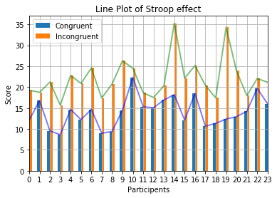

```python
stroop_data.plot(kind='bar')
stroop_data.Congruent.plot(kind = 'line', color = 'b',label = 'Congruent',linewidth=2,alpha = 0.5,grid = True)
stroop_data.Incongruent.plot(color = 'g',label = 'Incongruent',linewidth=2, alpha = 0.5,grid = True)
plt.xlabel('Participents')
plt.ylabel('Score')
plt.title('Line Plot of Stroop effect')
```

```
Text(0.5,1,'KDE of Stroop effect')
```

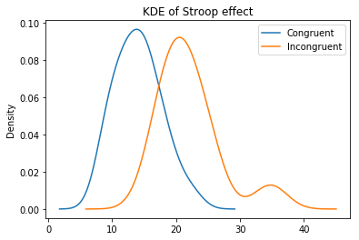

```python
stroop_data.plot.kde()
plt.title('KDE of Stroop effect')
```

(5) Now, perform the statistical test and report your results. What is your confidence level or Type I error associated with your test? What is your conclusion regarding the hypotheses you set up? Did the results match up with your expectations? **Hint:** Think about what is being measured on each individual, and what statistic best captures how an individual reacts in each environment.

```python
# Calculte the mean of each test
cong_mean = stroop_data['Congruent'].mean()
incong_mean = stroop_data['Incongruent'].mean()

# Calculte a point estimate using (mean_congurent - mean_incongurant) / Average of differences
estimate_point = cong_mean - incong_mean

# Calculate Square of Sums of difference of sample means
ssd = sum( ( (stroop_data['Congruent'] - stroop_data['Incongruent']) - estimate_point ) ** 2  )

# Calculate the variance of difference
vd = ssd / (24 -1)

# Calculate Standard Deviation of Differences
sdd = vd ** (1/2)


#  calculate the t-statistic for the difference
tstatistic = estimate_point / ( sdd / ( 24 ** (1/2) ) )

# Calculate the Degrees of Freedom (n -1)
df = 23

# Calculte the chances of seeing a result as extreme as the one we observed (known as the p-value)
pvalue = stats.t.cdf(x = tstatistic, df = 23 ) * 2

# Clacute t-critical for alpha level 0.005 (aiming to 99% confidence level)
alpha = 0.005
tcritical = stats.t.ppf(q=alpha, df=23)
```

```python
print("Degrees of Freedom : df =", df)
print("Alpha- level : a =", alpha)
print("t-critical values :  tc  =", -tcritical, tcritical)
print("t-Statistic(df) : t(23) =", tstatistic)
print("p-value : p =", pvalue)
```

```
Degrees of Freedom : df = 23
Alpha- level : a = 0.005
t-critical values :  tc  = 2.80733568377 -2.80733568377
t-Statistic(df) : t(23) = -8.02070694411
p-value : p = 4.10300058571e-08
```

The t-statistic is clearly smaller than the negative t-critical value and the critical reigion with a p-value < 0.0001.

**Therefore we can reject the Null Hypothesis with a 99% confidence interval and conclude there is a significant difference between congruent and incongruent tasks.**

These reuslts match what our observations and expectations that there is a statistically significant difference in the response.